# Mini-project 2: Logistic Regression with Newton’s Method

Department of Computer Science  
The University of Alabama at Birmingham  
Fall 2023, CS 667 / 767 Machine Learning

November 5th, 2023

Name: Sori Sim, Blazer ID: ssim

## Introduction

This mini-project aims to implement logistic regression with Newton's method to classify breast cancer data into benign and malignant cases. The performance of this implementation will be compared with scikit-learn's Logistic Regression to assess its accuracy and effectiveness.

## Data Information

The dataset used in this mini-project is the Breast Cancer Wisconsin dataset. Find more information about the dataset [here](http://archive.ics.uci.edu/ml/machine-learning-databases/breast-cancer-wisconsin/breast-cancer-wisconsin.data).  
(http://archive.ics.uci.edu/ml/machine-learning-databases/breast-cancer-wisconsin/breast-cancer-wisconsin.data)

## Import necessary libraries

```python
import sklearn
print(sklearn.__version__)
```

```
1.3.2
```

```python
!pip install --upgrade scikit-learn
!pip install --upgrade imbalanced-learn
!pip install matplotlib
```

[output not shown]

```python
!pip install matplotlib
```

```python
import numpy as np
import pandas as pd
from sklearn.model_selection import train_test_split
from sklearn.preprocessing import StandardScaler
from sklearn.metrics import accuracy_score
from imblearn.over_sampling import SMOTE
from sklearn.linear_model import LogisticRegression
import matplotlib.pyplot as plt
```

Set the tyle for plots

```python
plt.style.use('seaborn-v0_8-darkgrid')
```

## Loading the Data: Breast-cancer-wisconsin

1. Load the dataset

```python
url = "http://archive.ics.uci.edu/ml/machine-learning-databases/breast-cancer-wisconsin/breast-cancer-wisconsin.data"
column_names = ["ID", "CT", "UCSize", "UCShape", "MA", "SECSize", "BN", "BC", "NN", "Mitoses", "Diagnosis"]
data = pd.read_csv(url, names=column_names)
```

2. Replacing missing values ('?') with NaN
3. Labeling class: 2 for benign, 4 for malignant
4. Remove rows with missing values
5. Drop the 'ID' column

```python
data.replace('?', np.nan, inplace=True)
data['Diagnosis'] = data['Diagnosis'].map({2: 0, 4: 1})
data.dropna(inplace=True)
data.drop(['ID'], axis=1, inplace=True)

data_summary = data.describe()
print(data_summary.round(2))
```

```
           CT  UCSize  UCShape      MA  SECSize      BC      NN  Mitoses  \
count  683.00  683.00   683.00  683.00   683.00  683.00  683.00   683.00
mean     4.44    3.15     3.22    2.83     3.23    3.45    2.87     1.60
std      2.82    3.07     2.99    2.86     2.22    2.45    3.05     1.73
min      1.00    1.00     1.00    1.00     1.00    1.00    1.00     1.00
25%      2.00    1.00     1.00    1.00     2.00    2.00    1.00     1.00
50%      4.00    1.00     1.00    1.00     2.00    3.00    1.00     1.00
75%      6.00    5.00     5.00    4.00     4.00    5.00    4.00     1.00
max     10.00   10.00    10.00   10.00    10.00   10.00   10.00    10.00

       Diagnosis
count     683.00
mean        0.35
std         0.48
min         0.00
25%         0.00
50%         0.00
75%         1.00
max         1.00
```

## Data Visaulization

Let's check the data not only with the digit, but with eyes

```python
plt.style.use('seaborn-v0_8-darkgrid')
```

1. The Distribution of benign(B) and Malignant(M)

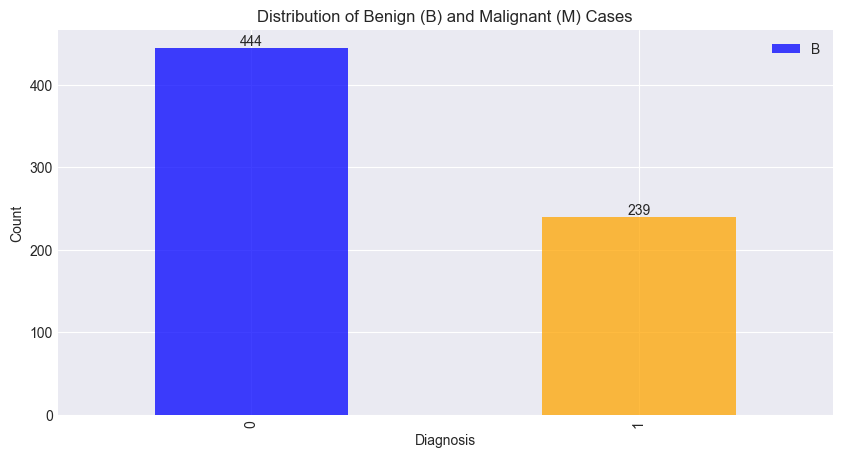

```python
# Count the number for each case
counts = data['Diagnosis'].value_counts()

plt.figure(figsize=(10, 5))
ax = counts.plot(kind='bar', color=['blue', 'orange'], alpha=0.75)
ax.set_xlabel('Diagnosis')
ax.set_ylabel('Count')
ax.set_title('Distribution of Benign (B) and Malignant (M) Cases')

for i in range(len(counts)):
    plt.text(i, counts[i], str(counts[i]), ha='center', va='bottom')

plt.legend(['B', 'M'], loc='upper right')

plt.show()
```

2. Mean values of the features

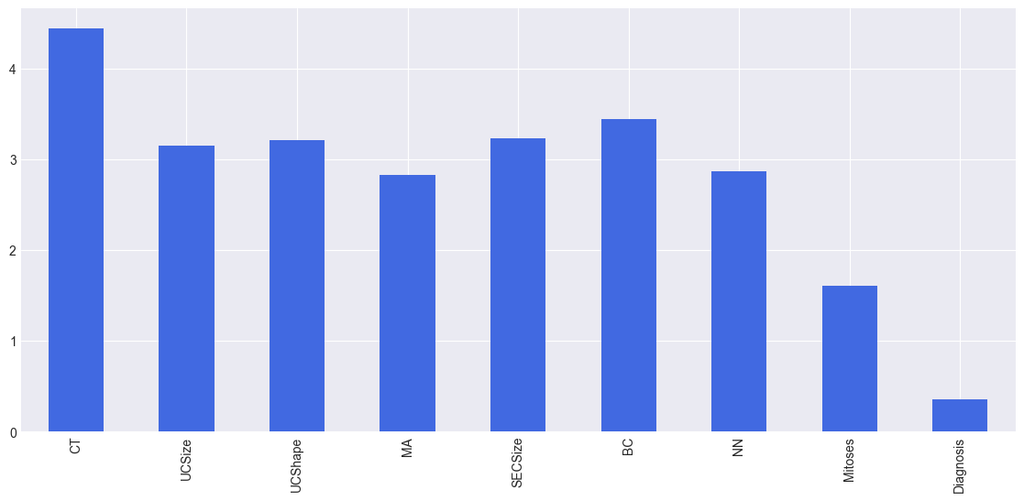

```python
fig, ax = plt.subplots(figsize=(14, 6))
data_mean = data.describe().loc['mean']
data_mean.plot(kind='bar', ax=ax, color='royalblue')

plt.show()
```

3. Relationship between the features

```
(683,) (683, 9)
```

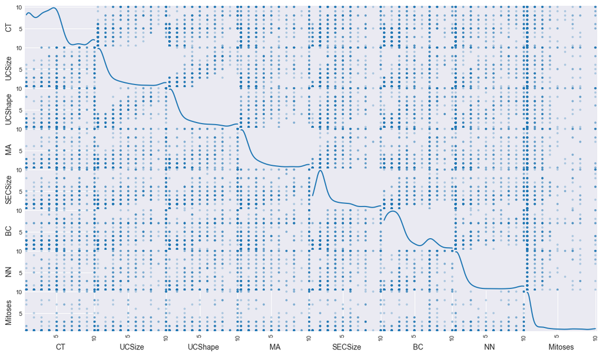

```python
diagnosis = data['Diagnosis']
features = data.drop(['Diagnosis'], axis = 1)

print(diagnosis.shape, features.shape)

pd.plotting.scatter_matrix(features, alpha = 0.3, figsize = (14,8), diagonal = 'kde');
```

## Data Splitting

1. Split the Data: Randomly sampling(80%), Model Testing(20%)

```python
X = features.values
y = diagnosis.values
```

2. Address class imbalance using SMOTE

```python
smote = SMOTE(random_state=None)
X_resampled, y_resampled = smote.fit_resample(X, y)
```

3. Split the resampled data: Training(80%), Testing(20%)

```python
X_train, X_test, y_train, y_test = train_test_split(X_resampled, y_resampled, test_size=0.2, random_state=None)
```

4. Standardize the features

```python
scaler = StandardScaler()
X_train = scaler.fit_transform(X_train)
X_test = scaler.transform(X_test)
```

## LogisticRegression with Newton's method & Result

1. Sigmoid Function for logistic regression

```python
# Sigmoid function for logistic regression
def sigmoid(x, w):
    z = x @ w
    return 1.0 / (1.0 + np.exp(-z))
```

2. Gradient of the Cost Function:

essential for finding the optimal model parameters using the Newton-Raphson method.

```python
# Gradient of the cost function
def gradient(X, y, w):
    m = X.shape[0]
    h = sigmoid(X, w)
    gradient = (1/m) * X.T @ (h - y)
    return gradient
```

3. Hessian Matrix for Newton's Method:

It's the second-order partial derivatives of the cost function and crucial for determining the curvature of the optimization surface.

```python
# Hessian matrix for Newton's method
def hessian(X, w):
    m = X.shape[0]
    h = sigmoid(X, w)
    S = np.diag(h * (1 - h))
    hessian = (1/m) * X.T @ S @ X
    return hessian
```

4. Implementation of Newton's Method:

Iterate Newton's Method to update the model parameters to minimize the cost function.

```python
def newtons_method(X, y, max_iterations=100, tolerance=1e-6, learning_rate=0.01, reg_strength=0.1):
    m, n = X.shape
    w = np.zeros(n)

    for i in range(max_iterations):
        gradient_vec = gradient(X, y, w)
        hessian_matrix = hessian(X, w)

        try:
            H_inv = np.linalg.inv(hessian_matrix)
        except np.linalg.LinAlgError:
            # Regularize the Hessian matrix if it's singular
            hessian_matrix += reg_strength * np.identity(hessian_matrix.shape[0])
            H_inv = np.linalg.inv(hessian_matrix)

        Δ = H_inv @ gradient_vec
        w -= learning_rate * Δ

        h = sigmoid(X, w)
        # Calculate the cost function
        cost = (1/m) * (-y.T @ np.log(h) - (1 - y).T @ np.log(1 - h))
        if cost < tolerance:
            break

    return w
```

5. Execute multiple trials:

To estimate the generalization performance

```python
num_trials = 10
accuracies = []

print("-------------------------Result------------------------- \n")

for trial in range(num_trials):
    X = data.drop(['Diagnosis'], axis=1).values
    y = data['Diagnosis'].values

    smote = SMOTE(random_state=None)
    X_resampled, y_resampled = smote.fit_resample(X, y)

    scaler = StandardScaler()
    X_train, X_test, y_train, y_test = train_test_split(X_resampled, y_resampled, test_size=0.2, random_state=None)  # Random split
    X_train = scaler.fit_transform(X_train)
    X_test = scaler.transform(X_test)

    # Train the model using Newton's method
    w = newtons_method(X_train, y_train, max_iterations=100, tolerance=1e-6, learning_rate=0.01, reg_strength=0.1)


    predictions = sigmoid(X_test, w) >= 0.5

    right = np.sum(predictions == y_test)
    wrong = len(y_test) - right
    accuracy_rate = right / (right + wrong)

    # Print the results
    print(f"Trial {trial + 1}:")
    print(f"Correct predictions: {right}")
    print(f"Incorrect predictions: {wrong}")
    print(f"Accuracy: {accuracy_rate:.2f} \n")


    # Make predictions
    y_pred = (sigmoid(X_test, w) >= 0.5).astype(int)
    accuracy = accuracy_score(y_test, y_pred)
    accuracies.append(accuracy)


# Calculate the mean accuracy and standard deviation
print("---------------------------------------------------------------------------------")
mean_accuracy = np.mean(accuracies)
std_dev = np.std(accuracies)
print(f"Mean Accuracy: {mean_accuracy:.2f}")
print(f"Standard Deviation: {std_dev:.2f}")
print("---------------------------------------------------------------------------------")
```

```
-------------------------Result-------------------------

Trial 1:
Correct predictions: 171
Incorrect predictions: 7
Accuracy: 0.96

Trial 2:
Correct predictions: 173
Incorrect predictions: 5
Accuracy: 0.97

Trial 3:
Correct predictions: 170
Incorrect predictions: 8
Accuracy: 0.96

Trial 4:
Correct predictions: 169
Incorrect predictions: 9
Accuracy: 0.95

Trial 5:
Correct predictions: 166
Incorrect predictions: 12
Accuracy: 0.93

Trial 6:
Correct predictions: 169
Incorrect predictions: 9
Accuracy: 0.95

Trial 7:
Correct predictions: 172
Incorrect predictions: 6
Accuracy: 0.97

Trial 8:
Correct predictions: 173
Incorrect predictions: 5
Accuracy: 0.97

Trial 9:
Correct predictions: 173
Incorrect predictions: 5
Accuracy: 0.97

Trial 10:
Correct predictions: 174
Incorrect predictions: 4
Accuracy: 0.98

---------------------------------------------------------------------------------
Mean Accuracy: 0.96
Standard Deviation: 0.01
---------------------------------------------------------------------------------
```

## Verify the Model: Scikit-learn's Logistic Regression

1. Use sklearn: Scikit-learn Logistic Regression

Check the accuracy

```python
sklearn_model = LogisticRegression(max_iter=100, C=1.0)
sklearn_model.fit(X_train, y_train)
sklearn_predictions = sklearn_model.predict(X_test)
sklearn_accuracy = accuracy_score(y_test, sklearn_predictions)

print("Scikit-learn's Logistic Regression Accuracy:", sklearn_accuracy)
```

```
Scikit-learn's Logistic Regression Accuracy: 0.9887640449438202
```

2. Compare the result:

Compare my result with the Scikit-learn's Logistic regression to check if I get the right accuracy from the Prediction Model

```python
my_accuracy = accuracy_rate

print("Verify My Model's accuracy with Scikit-learn's Logistic Regression")
print("---------------------------------------------------------------------------------")
print("My Model's Accuracy:", my_accuracy)
print("Scikit-learn's Logistic Regression Accuracy:", sklearn_accuracy)

accuracy_difference = my_accuracy - sklearn_accuracy
print("Accuracy Difference:", accuracy_difference)
print("---------------------------------------------------------------------------------")
```

[output not shown]